# A reproducible analysis in R

Stefano De Sabbata

This document is an small example of a reproducible analysis. This is an R Markdown script created in RStudio, which uses the *rmarkdown*, *knitr*, and *dyplr* libraries of the [Tidyverse](https://www.tidyverse.org/). Data from the [UK Department for Transport](https://www.gov.uk/government/organisations/department-for-transport) are analysed and the output is compiled in a *pdf* document.

# Data

This analysis document depends on *Gather_DfT_data_2015.R*, which retrieves some data from the Department for Transport and saves them in the *Data* folder. It is assumed that *Gather_DfT_data_2015.R* has been executed before this document is compiled.

The data file is relatively large and it is available in compressed *zip* format. It is thus necessary to download the file and process it locally before reading it in to R. The *download.file* and *unzip* functions can be used to read in data: *download.file* takes two arguments, the URL of the file to download, and the name of a local file into which it will be stored. The function *unzip* takes at minimum one argument, which is the file to be unzipped. It is possible to specify the folder in which the files should be extracted to (see *?unzip*). In this case, once the function has been executed, the files contained in the zip file are available in the working *Data* folder.

The *Gather_DfT_data_2015.R* script is executed by the *Make.R* script. For your own understanding of the process, read the code in *Gather_DfT_data_2015.R* and then execute it by clicking on the *Source* button on the top-right of the code when the file is open on RStudio.

# Libraries and Packages

This document assumes that the whole Tidyverse is installed. If not already installed, please install Tidyverse before cloning the repository, using the command below or via the *Tools > Install Packages* menu in RStudio.

```r
install.packages("tidyverse")
```

Before staring, let’s then load the *knitr* library that we need to use *kable* to create nice tables in R Markdown.

```r
# Load knitr
library(knitr)
```

# Loading the data

R can import a number of different types of data files. One of the most commonly used format is the *.csv* (comma separated values). Before continuing, make sure the *Data* folder contains the *Accidents_2015.csv* file. If not, you can execute the *Gather_DfT_data_2015.R* script in the *Dat* folder, or the *Make.R* script.

You can open the *Accidents_2015.csv* file using Notepad (or another text editor) to see its text format, and using Microsoft Excel (or similar software) to see the tabular structure. The code below loads the data from the file using the *read.csv* function into a *data.frame* variable named *accidents*. The function *head* is used to grab only the top rows to be displayed in this document. In this case, the code specifies to grab only the first five rows (*n = 5*). Those five row are the displayed using the *kable* function mentioned above, which create a well-formatted table.

Note that when this document is compiled, the *working directory* is the folder where the document is. Thus, the path to the *Data* files needs to start from within the *Analysis* folder, up one level to the main folder (using *../*) and then in the *Data* folder.

```r
# Load data about accidents
accidents <- read.csv("../Data/Accidents_2015.csv")

# Inspect the content in data frame
# Only a subset of columns is selected
kable(head(
  accidents[,
    c("Accident_Index", "Date", "Time", "Local_Authority_.District.")
  ],
  n = 5
))
```

| Accident_Index | Date | Time | Local_Authority_.District. |
| --- | --- | --- | --- |
| 201501BS70001 | 12/01/2015 | 18:45 | 12 |
| 201501BS70002 | 12/01/2015 | 07:50 | 12 |
| 201501BS70004 | 12/01/2015 | 18:08 | 12 |
| 201501BS70005 | 13/01/2015 | 07:40 | 12 |
| 201501BS70008 | 09/01/2015 | 07:30 | 12 |

# A simple analysis

The analysis below uses *dplyr*, which is another useful library that is part of the Tidyverse. The functions provided by *dplyr* are frequently used in scripts that employ a [pipe-based programming](http://r4ds.had.co.nz/pipes.html) style. This is not covered in this lecture, but *Gather_Ofcom_data_2012.R* provides an example of that approach. The chunk of code below loads the *dyplr* library.

```r
# The warn.conflicts and quietly options can be used
# to suppress the message on loading
library(dplyr, warn.conflicts = FALSE, quietly = TRUE)
```

The function *count* of the *dplyr* library can be used to count the number rows of a *data.frame*, grouped by a variable (in the example below, the local authority district). As you can see, the code below is formatted in a way similar to a code block, although it is not a code block. This is very common in R programming (especially when functions have a lot of parameters) as it makes the code more readable.

```r
# Count number of accident by local authority
accidents_count <- count(
  accidents,
  Local_Authority_.District.
  )

# Inspect the content in data frame
kable(head(accidents_count, n=5))
```

| Local_Authority_.District. | n |
| --- | --- |
| 1 | 1578 |
| 2 | 936 |
| 3 | 844 |
| 4 | 857 |
| 5 | 1066 |

The function *summarise* of the same library *dplyr* can be used in combination with the function *group_by* to summarise the values of the rows of a *data.frame*. Rows can be grouped by a variable (in the example below, whether an area is urban or rural), and then aggregated based on a function over one or more columns. In this example the function is *mean*, over the column *Accident_Severity* (where numeric values range from 1, for the most sever, to 3, for the less sever accidents).

```r
# Group accidents by Urban and Rural areas
accidents_urb_rrl <-group_by(
    accidents,
    Urban_or_Rural_Area
  )

# Average severity per Urban and Rural areas
accidents_urb_rrl_severity <- summarise(
  accidents_urb_rrl,
  avg_severity = mean(Accident_Severity)
)

# Inspect the content in data frame
kable(accidents_urb_rrl_severity)
```

| Urban_or_Rural_Area | avg_severity |
| --- | --- |
| 1 | 2.861045 |
| 2 | 2.781662 |

The same result can be achieved by inserting the call to the function *group_by* directly into the call to the function *summarise*, as first argument. Observe the code below and compare to the code above.

```r
# Group and average severity per Urban and Rural areas
accidents_urb_rrl_severity <- summarise(
  group_by(
    accidents,
    Urban_or_Rural_Area
  ),
  avg_severity = mean(Accident_Severity)
)

# Inspect the content in data frame
kable(accidents_urb_rrl_severity)
```

| Urban_or_Rural_Area | avg_severity |
| --- | --- |
| 1 | 2.861045 |
| 2 | 2.781662 |

The same result can also be achieved by using the *aggregate* function of the *stats* library, which does not need to be loaded as it is part of the base R libraries. Observe the code below and compare to the two chunks of code above.

Note that in the code below, a copy of the *data.frame* containing only the *Urban_or_Rural_Area* and *Accident_Severity* column is first created, as the aggregation function specified as argument for *FUN* is applied to all columns in the table except the group-by column specified as argument for *by*.

```r
# Average severity per Urban and Rural areas
accidents_copy <- accidents[, c("Urban_or_Rural_Area", "Accident_Severity")]
accidents_urb_rrl_severity <- aggregate(
  accidents_copy,
  by = list(accidents_copy$Urban_or_Rural_Area),
  FUN = mean
)

# Inspect the content in data frame
kable(accidents_urb_rrl_severity)
```

| Group.1 | Urban_or_Rural_Area | Accident_Severity |
| --- | --- | --- |
| 1 | 1 | 2.861045 |
| 2 | 2 | 2.781662 |

# Mergind datasets

As mentioned in previous lectures, two tables can be merged using a common column of identifiers. We can thus load a second dataset, containing the information about the vehicles involved in the accidents. In this case, one or more vehicles will be involved for each accidents.

```r
# Load data about vehicles
vehicles <- read.csv("../Data/Vehicles_2015.csv")

# Inspect the content in data frame
# Only a subset of columns is selected
kable(head(
  vehicles[,
    c("Accident_Index", "Vehicle_Type", "Age_of_Vehicle")
  ],
  n = 10
))
```

| Accident_Index | Vehicle_Type | Age_of_Vehicle |
| --- | --- | --- |
| 201506E098757 | 9 | 11 |
| 201506E098766 | 9 | 1 |
| 201506E098766 | 9 | -1 |
| 201506E098777 | 20 | 1 |
| 201506E098780 | 9 | -1 |
| 201506E098780 | 1 | -1 |
| 201506E098792 | 3 | 8 |
| 201506E098792 | 9 | 10 |
| 201506E098804 | 9 | 1 |
| 201506E098826 | 9 | 8 |

The two tables can be merged using the function *merge*, and specify the common column (or columns, if more than one is to be used as identifier) as argument of *by*.

```r
# Merge the data
accidents_vehicles <- merge(accidents, vehicles, by = "Accident_Index")

# Inspect the content in data frame
# Only a subset of columns is selected
kable(head(
  accidents_vehicles[,
    c("Accident_Index", "Urban_or_Rural_Area", "Accident_Severity",
      "Vehicle_Type", "Age_of_Vehicle")
  ],
  n = 5
))
```

| Accident_Index | Urban_or_Rural_Area | Accident_Severity | Vehicle_Type | Age_of_Vehicle |
| --- | --- | --- | --- | --- |
| 201501BS70001 | 1 | 3 | 19 | 4 |
| 201501BS70002 | 1 | 3 | 9 | 3 |
| 201501BS70004 | 1 | 3 | 9 | 10 |
| 201501BS70005 | 1 | 3 | 9 | -1 |
| 201501BS70008 | 1 | 2 | 1 | -1 |

The average and standard deviation age of the vehicles involved in an accident per accident severity can then be calculated using the code below. Note how the second aggregation function *sd* (standard deviation) is added after the first aggregation function, to create a second column of aggregated values.

```r
# Group and average severity per Urban and Rural areas
accidents_vehicles_severity_age <- summarise(
  group_by(
    accidents_vehicles,
    Accident_Severity
  ),
  avg_age = mean(Age_of_Vehicle),
  stddev_age = sd(Age_of_Vehicle)
)

# Inspect the content in data frame
kable(accidents_vehicles_severity_age)
```

| Accident_Severity | avg_age | stddev_age |
| --- | --- | --- |
| 1 | 5.929286 | 6.227915 |
| 2 | 5.123257 | 6.280692 |
| 3 | 5.148115 | 5.815070 |

Finally, images can be included in *RMarkdown* documents by simply adding the corresponding code. The boxplot can be created using the *boxplot* function of the base library *graphics*. The first arguments requires the name of the variable to be shown on the y-axis and the name of the variable to be used to categorise the cases on the x-axis, separate by a *tilde* symbol. The data to be used in specified using the *data* parameter. The example below also illustrate (in the RMarkdown code) how to specify the caption and size of the figure using the arguments of the code chunk.

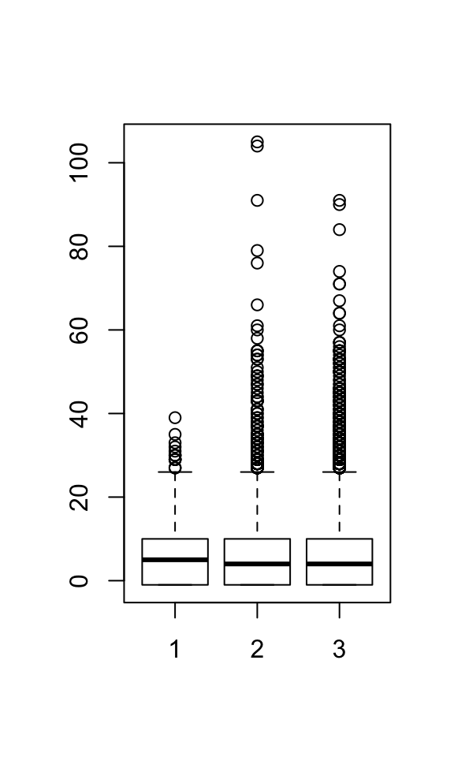

Age of vehicles per accident severity

```r
boxplot(Age_of_Vehicle ~ Accident_Severity, data = accidents_vehicles)
```

# Exercise

Add another section of R code below, that creates a new column for the *accidents* dataset, which represents the hour of the accident – e.g., from *18:45* to *18*. That can be achieved using the function *substr* (to select a section of a character variable, see *?substr*) on the column *Time* and the converting the result *as.numeric*.

Once the first part above is completed, calculate the number of accidents per hour of the day in which the accident happened, and then the average severity per hour of the day. Then, merge the *accidents* and *vehicles* again, and calculate the average age of the driver per hour of the day.

Solutions are provided in the script *Reproducible_analysis_Exercise_solution.R* in the *Analysis* folder.